# MO. 157 Análisis de datos ómicos. PEC 2

Rubén Jové Nieto

14/6/2020

Enlace al repositorio de github.

https://github.com/rbenjn/PEC_02

## Objetivos

El objetivo de este análisis es comparar y obtener las diferencias significativas resultado de realizar un análisis de expresión diferencia. También así poder constatar las posibles diferencias entre los 3 grupos a partir de los datos de expresión.

## Materiales y métodos

Para obtener la muestra de n = 30 de manera aleatoria se realizó un pequeño script mediante R. A través de los 2 archivos: ‘targets’ y ‘counts’, se construyó la muestra de estudio.

Mediante R y BioConductor se realizó el análisis de datos. Utilizando el paquete DESeq2 para el análisis de los datos de expresión (RNA-seq).

El análisis de significación biológica se hizó mediante el enriquicimiento del conjunto de genes con ClusterProfiler.

Se realizarán 3 comparaciones: -NIT vs SFI -SFI vs ELI -ELI vs NIT

### “Pipeline” análisis

Los pasos o “pipeline” seguido para el análisis han sido:

1. Identificar que grupos hay y a qué grupo pertenece cada muestra.
2. Preprocesado de los datos: filtraje y normalización
3. Identificación de genes diferencialmente expresados
4. Anotación de los resultados
5. Busca de patrones de expresión y agrupación de las muestras(Comparación entre distintas comparaciones )
6. Análisis de significación biológica (“Gene Enrichment Analysis”)

### “Pipeline” ampliada

#### 1. Identificar que grupos hay y a qué grupo pertenece cada muestra.

En primer lugar, importamos los 2 distintos archivos: ‘targets.csv’ y ‘counts.csv’ a R.

A continuación, creamos un script que nos permita extraer 10 muestras de cada grupo (NIT, SFI y ELI). Para ello, utilizamos la información de la columna ‘Group’ en el archivo ‘targets’. Dicho script nos aseguraremos que sea reproducible y aleatorio mediante ‘set.seed’.

Así quedaría el dataframe con las muestras escogidas.

| Experiment | SRA_Sample | Sample_Name | Grupo_analisis | body_site | molecular_data_type | sex | Group | ShortName |
| --- | --- | --- | --- | --- | --- | --- | --- | --- |
| SRX624616 | SRS646000 | GTEX-ZVP2-0426-SM-57WC2 | 1 | Thyroid | RNA Seq (NGS) | male | NIT | ZVP2-_NIT |
| SRX589853 | SRS634351 | GTEX-145MH-0426-SM-5LU8T | 1 | Thyroid | RNA Seq (NGS) | male | NIT | 145MH_NIT |
| SRX572499 | SRS627895 | GTEX-13O61-0226-SM-5KM52 | 1 | Thyroid | RNA Seq (NGS) | male | NIT | 13O61_NIT |
| SRX597647 | SRS637302 | GTEX-11I78-0526-SM-5986A | 1 | Thyroid | RNA Seq (NGS) | female | NIT | 11I78_NIT |
| SRX222627 | SRS389690 | GTEX-QV31-0726-SM-3GAEG | 1 | Thyroid | Allele-Specific Expression | male | NIT | QV31-_NIT |
| SRX559141 | SRS624025 | GTEX-1122O-0226-SM-5N9DA | 1 | Thyroid | RNA Seq (NGS) | female | NIT | 1122O_NIT |

Una vez tenemos las filas escogidas, 10 muestras para cada grupo, procedemos a ‘cruzar’ o ‘subsetear’ las columnas escogidas en el archivo ‘counts.csv’.

Obtenemos entonces, el dataframe ‘countdata’ con 30 variables, 10 para cada grupo, de manera aleatoria.

Una vez tenemos la dataframe, podemos ya construir el objeto DESeqDataSet.

#### 2. Preprocesado de los datos: filtraje y normalización

Procedemos a filtrar los datos ya que nuestro DESeqDataSet tiene filas con 0. Lo hacemos con el fin de reducir el tamaño del ‘dds’ y así agilizar las funciones.

```
## [1] 56202
```

```
## [1] 43699
```

Pasando tener de 56.202 filas a 43.699.

Para poder estabilizar la varianza de los datos, usaremos la función VST (para medios-grandes datasets, n > 30)

```
##                        1.1      1.2      1.3      1.4      1.5      1.6
## ENSG00000223972.4 4.475310 4.363455 4.229991 4.372187 4.385326 4.255178
## ENSG00000227232.4 9.234145 9.273780 9.460894 9.209663 9.094404 9.800575
## ENSG00000243485.2 4.168691 3.628672 4.055396 3.628672 4.499164 4.073405
##                        1.7      1.8      1.9     1.10       2.1      2.2
## ENSG00000223972.4 4.239974 4.286512 4.659221 4.034320  4.197054 4.211554
## ENSG00000227232.4 8.933064 8.679066 8.807334 9.833603 10.141167 9.725608
## ENSG00000243485.2 3.628672 4.688274 4.152096 3.628672  3.958237 4.300234
##                        2.3      2.4      2.5      2.6      2.7      2.8
## ENSG00000223972.4 4.297062 4.047944 4.242781 4.263899 4.269980 3.628672
## ENSG00000227232.4 9.879822 9.882746 9.933560 9.099115 9.587032 9.487858
## ENSG00000243485.2 4.297062 4.787338 4.064539 3.628672 4.153718 3.628672
##                        2.9     2.10      3.1      3.2       3.3       3.4
## ENSG00000223972.4 4.328987 4.223164 4.902760 3.628672  4.322605  4.687723
## ENSG00000227232.4 8.907394 8.997709 8.919048 9.661885 10.332883 10.216479
## ENSG00000243485.2 3.628672 4.050517 4.379890 3.990921  4.031874  4.069089
##                        3.5      3.6      3.7      3.8      3.9     3.10
## ENSG00000223972.4 4.006336 4.222429 4.457829 3.628672 3.950132 3.628672
## ENSG00000227232.4 9.420341 9.487709 8.765157 9.895897 9.864630 9.982187
## ENSG00000243485.2 4.161267 4.222429 4.003551 4.062134 3.950132 4.073130
```

```
## DataFrame with 30 rows and 10 columns
##       Experiment  SRA_Sample              Sample_Name Grupo_analisis
##      <character> <character>              <character>      <numeric>
## 1.1    SRX624616   SRS646000  GTEX-ZVP2-0426-SM-57WC2              1
## 1.2    SRX589853   SRS634351 GTEX-145MH-0426-SM-5LU8T              1
## 1.3    SRX572499   SRS627895 GTEX-13O61-0226-SM-5KM52              1
## 1.4    SRX597647   SRS637302 GTEX-11I78-0526-SM-5986A              1
## 1.5    SRX222627   SRS389690  GTEX-QV31-0726-SM-3GAEG              1
## ...          ...         ...                      ...            ...
## 3.6    SRX222429   SRS389623  GTEX-TMMY-0826-SM-33HB9              3
## 3.7    SRX199272   SRS333099  GTEX-PLZ4-1226-SM-2I5FE              3
## 3.8    SRX601511   SRS638114 GTEX-13QJC-0826-SM-5RQKC              3
## 3.9    SRX615373   SRS644099  GTEX-YFC4-2626-SM-5P9FQ              3
## 3.10   SRX607358   SRS639491 GTEX-14AS3-0226-SM-5Q5B6              3
##        body_site        molecular_data_type         sex    Group   ShortName
##      <character>                <character> <character> <factor> <character>
## 1.1      Thyroid              RNA Seq (NGS)        male      NIT   ZVP2-_NIT
## 1.2      Thyroid              RNA Seq (NGS)        male      NIT   145MH_NIT
## 1.3      Thyroid              RNA Seq (NGS)        male      NIT   13O61_NIT
## 1.4      Thyroid              RNA Seq (NGS)      female      NIT   11I78_NIT
## 1.5      Thyroid Allele-Specific Expression        male      NIT   QV31-_NIT
## ...          ...                        ...         ...      ...         ...
## 3.6      Thyroid Allele-Specific Expression      female      ELI   TMMY-_ELI
## 3.7      Thyroid              RNA Seq (NGS)      female      ELI   PLZ4-_ELI
## 3.8      Thyroid Allele-Specific Expression      female      ELI   13QJC_ELI
## 3.9      Thyroid Allele-Specific Expression      female      ELI   YFC4-_ELI
## 3.10     Thyroid              RNA Seq (NGS)      female      ELI   14AS3_ELI
##      sizeFactor
##       <numeric>
## 1.1    1.140662
## 1.2    0.915051
## 1.3    0.917387
## 1.4    0.893225
## 1.5    0.861796
## ...         ...
## 3.6    1.411864
## 3.7    1.190652
## 3.8    0.888879
## 3.9    1.621658
## 3.10   0.845116
```

También podríamos realizar la transformación con ‘rlog’, que funciona mejor con muestras pequeñas (n < 30). De hecho así nos lo muestra el mensaje que aparece en la consola, recomendando vst().

```
## rlog() may take a few minutes with 30 or more samples,
## vst() is a much faster transformation
```

```
##                        1.1       1.2       1.3       1.4       1.5       1.6
## ENSG00000223972.4 1.465206 1.3497010 1.2271724 1.3576602 1.3695933 1.2494382
## ENSG00000227232.4 9.244778 9.2748751 9.4169384 9.2263860 9.1394694 9.6767440
## ENSG00000243485.2 0.570240 0.3171452 0.4809149 0.3184021 0.8764663 0.4945403
##                         1.7      1.8       1.9      1.10      2.1       2.2
## ENSG00000223972.4 1.2360223 1.278669 1.6700358 1.0701847 1.194665 1.2083355
## ENSG00000227232.4 9.0182543 8.828270 8.9232865 9.7022270 9.940065 9.6193553
## ENSG00000243485.2 0.3187547 1.087587 0.5578084 0.3118624 0.406815 0.6954525
##                         2.3      2.4       2.5       2.6       2.7       2.8
## ENSG00000223972.4 1.2859746 1.081953 1.2385051 1.2570987 1.2632292 0.9239201
## ENSG00000227232.4 9.7376322 9.740030 9.7791573 9.1430631 9.5131781 9.4374740
## ENSG00000243485.2 0.6760885 1.181256 0.4878439 0.3229192 0.5576887 0.3148990
##                         2.9      2.10       3.1       3.2        3.3       3.4
## ENSG00000223972.4 1.3180682 1.2211035 1.7888488 0.9035137  1.3121753 1.6726987
## ENSG00000227232.4 8.9988475 9.0666693 9.0107554 9.5704655 10.0888800 9.9981716
## ENSG00000243485.2 0.3121827 0.4772097 0.6969553 0.4316937  0.4630059 0.4912835
##                        3.5       3.6       3.7       3.8       3.9      3.10
## ENSG00000223972.4 1.045901 1.2185806 1.4483669 0.9295448 0.9971832 0.9335508
## ENSG00000227232.4 9.386057 9.4373607 8.8923010 9.7501269 9.7262836 9.8166640
## ENSG00000243485.2 0.564019 0.6204204 0.4413517 0.4860236 0.4006927 0.4943332
```

Mostramos en plot la comparativa de ambos resultados de transformación de los datos:

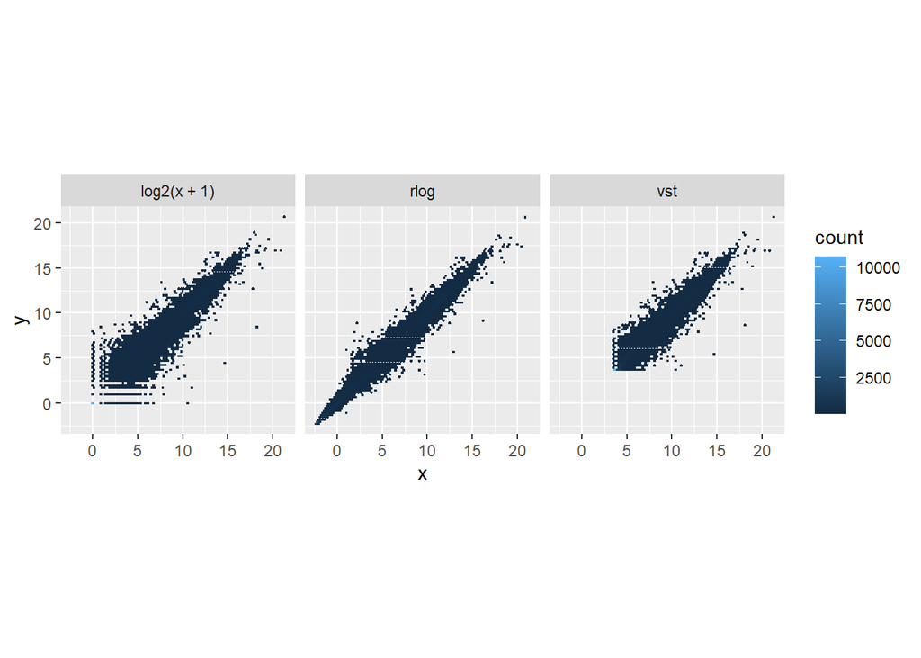

Utilizando los resultados de VST, es decir el objeto ‘vsd’ en el análisis, podemos evaluar la similitud general entre muestras. Podemos evaluar si son similares entre ellas o diferentes, así poder hacernos una primera idea si cumple con lo esperado con el análisis. La función ‘sampleDists’ para calcular las distancias entre las muestras nos ayuda a ello.

Podemos observar una mayor distancia en muestras de distintos grupos, es decir entre las del grupo 1 NIT (1.1-1.10) hay una menor distancia, en cambio esta aumenta al compararse con las del grupo 3 ELI por ejemplo.

Lo visualizamos en el siguiente mapa de calor:

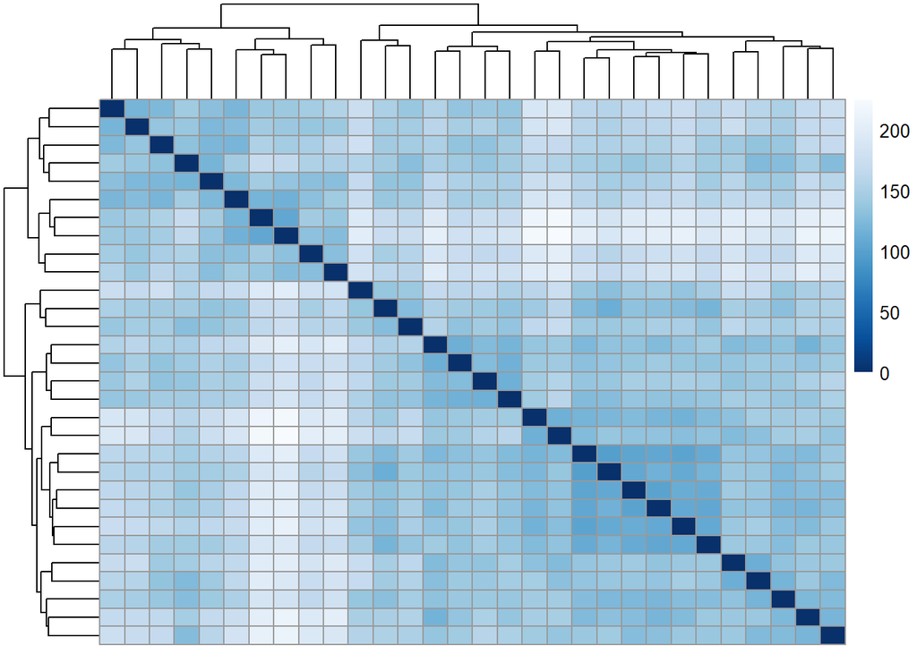

Realizamos el gráfico PCA para cada grupo con los datos obtenidos de VST también:

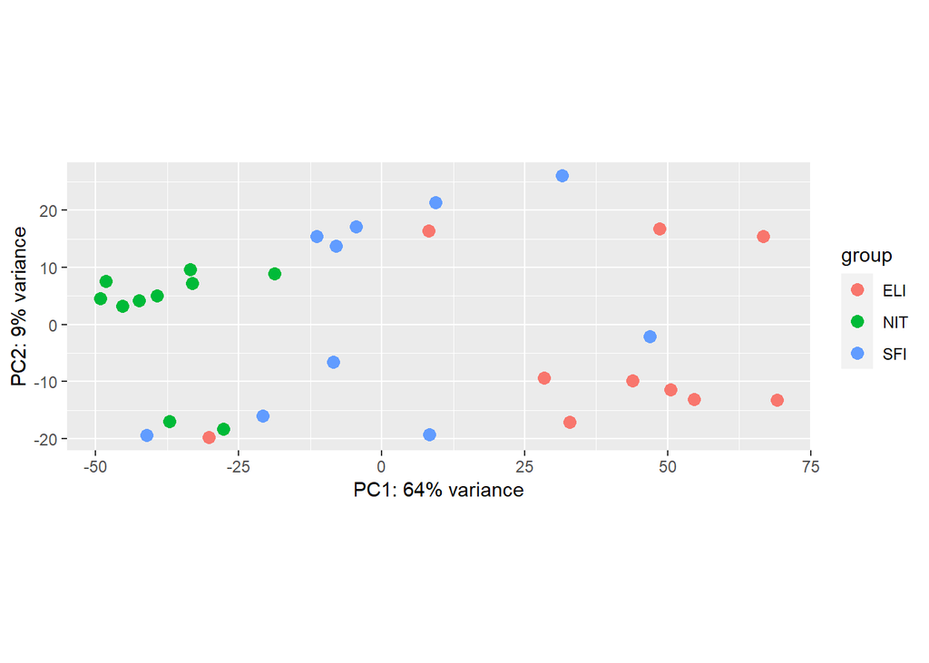

Podemos observar cada color para cada grupo y su varianza, surgiendo ciertos patrones similares según grupo.

#### 3. Identificación de genes diferencialmente expresados

Utilizamos la función ‘DESeq’ en nuestro objeto creado ‘dds’, para así luego poder de este obtener los resultados que nos interesan a partir de la opción ‘contrast’, indicando el factor ‘Group’ que es donde obtenemos los 3 distintos grupos según infiltración tiroídea y las consecuentes comparaciones.

Mostraremos un resumen de los resultados para cada comparación.

#### NIT vs ELI

```
##
## out of 43697 with nonzero total read count
## adjusted p-value < 0.1
## LFC > 0 (up)       : 3171, 7.3%
## LFC < 0 (down)     : 5147, 12%
## outliers [1]       : 0, 0%
## low counts [2]     : 11863, 27%
## (mean count < 1)
## [1] see 'cooksCutoff' argument of ?results
## [2] see 'independentFiltering' argument of ?results
```

#### NIT vs SFI

```
##
## out of 43697 with nonzero total read count
## adjusted p-value < 0.1
## LFC > 0 (up)       : 430, 0.98%
## LFC < 0 (down)     : 1178, 2.7%
## outliers [1]       : 0, 0%
## low counts [2]     : 16099, 37%
## (mean count < 2)
## [1] see 'cooksCutoff' argument of ?results
## [2] see 'independentFiltering' argument of ?results
```

#### ELI vs SFI

```
##
## out of 43697 with nonzero total read count
## adjusted p-value < 0.1
## LFC > 0 (up)       : 2501, 5.7%
## LFC < 0 (down)     : 1169, 2.7%
## outliers [1]       : 0, 0%
## low counts [2]     : 15251, 35%
## (mean count < 2)
## [1] see 'cooksCutoff' argument of ?results
## [2] see 'independentFiltering' argument of ?results
```

Con los datos obtenidos, podemos proceder a extraer y aquellos significativos. Teniendo en cuenta un posible 10% de falsos positivos, para cada comparación obtenemos:

NIT vs ELI: 8318 genes significativos

NIT vs SFI: 1608 genes significativos

ELI vs SFI: 3670 genes significativos

Posteriormente podemos identificar y mostrar aquellos que están down-regulated para cada comparación:

```
## log2 fold change (MLE): Group NIT vs ELI
## Wald test p-value: Group NIT vs ELI
## DataFrame with 6 rows and 6 columns
##                     baseMean log2FoldChange     lfcSE      stat      pvalue
##                    <numeric>      <numeric> <numeric> <numeric>   <numeric>
## ENSG00000181617.5   381.3621       -9.90648  1.649666  -6.00514 1.91166e-09
## ENSG00000222037.5   797.3926       -9.79812  0.960263 -10.20358 1.91095e-24
## ENSG00000223350.2   136.8381       -9.69551  1.286652  -7.53546 4.86624e-14
## ENSG00000170054.10   55.1950       -9.25324  1.314936  -7.03702 1.96389e-12
## ENSG00000253274.1    69.1401       -9.06199  1.219109  -7.43328 1.05934e-13
## ENSG00000117215.10  138.4381       -8.98663  1.188865  -7.55900 4.06169e-14
##                           padj
##                      <numeric>
## ENSG00000181617.5  9.67562e-08
## ENSG00000222037.5  1.71518e-20
## ENSG00000223350.2  7.17229e-12
## ENSG00000170054.10 1.94169e-10
## ENSG00000253274.1  1.41703e-11
## ENSG00000117215.10 6.07080e-12
```

```
## log2 fold change (MLE): Group NIT vs SFI
## Wald test p-value: Group NIT vs SFI
## DataFrame with 6 rows and 6 columns
##                    baseMean log2FoldChange     lfcSE      stat      pvalue
##                   <numeric>      <numeric> <numeric> <numeric>   <numeric>
## ENSG00000211946.2  119.3200      -10.18393  1.256589  -8.10442 5.29972e-16
## ENSG00000222037.5  797.3926       -8.34657  0.960361  -8.69107 3.59026e-18
## ENSG00000235896.2   59.0700       -8.33345  1.418771  -5.87371 4.26141e-09
## ENSG00000242371.1 2169.5790       -8.02743  0.905127  -8.86884 7.39089e-19
## ENSG00000253274.1   69.1401       -7.86274  1.219781  -6.44602 1.14823e-10
## ENSG00000211619.2   65.4272       -7.81824  1.406149  -5.56004 2.69717e-08
##                          padj
##                     <numeric>
## ENSG00000211946.2 2.99401e-12
## ENSG00000222037.5 4.95456e-14
## ENSG00000235896.2 1.50788e-06
## ENSG00000242371.1 2.03988e-14
## ENSG00000253274.1 6.46756e-08
## ENSG00000211619.2 7.09057e-06
```

```
## log2 fold change (MLE): Group ELI vs SFI
## Wald test p-value: Group ELI vs SFI
## DataFrame with 6 rows and 6 columns
##                     baseMean log2FoldChange     lfcSE      stat      pvalue
##                    <numeric>      <numeric> <numeric> <numeric>   <numeric>
## ENSG00000108342.8  108.06374       -3.81297  0.865798  -4.40400 1.06272e-05
## ENSG00000236136.1    2.89710       -3.43413  1.308220  -2.62504 8.66378e-03
## ENSG00000089225.15 253.92977       -2.98068  0.728853  -4.08955 4.32216e-05
## ENSG00000241717.1    9.57786       -2.86229  0.933100  -3.06751 2.15852e-03
## ENSG00000225893.1    3.14491       -2.79170  0.801341  -3.48378 4.94380e-04
## ENSG00000228036.1    2.19718       -2.76013  1.084950  -2.54402 1.09585e-02
##                           padj
##                      <numeric>
## ENSG00000108342.8  0.000581392
## ENSG00000236136.1  0.078070097
## ENSG00000089225.15 0.001766620
## ENSG00000241717.1  0.031109474
## ENSG00000225893.1  0.010944981
## ENSG00000228036.1  0.090231074
```

Y los que están up-regulated para cada comparación:

```
## log2 fold change (MLE): Group NIT vs ELI
## Wald test p-value: Group NIT vs ELI
## DataFrame with 6 rows and 6 columns
##                    baseMean log2FoldChange     lfcSE      stat      pvalue
##                   <numeric>      <numeric> <numeric> <numeric>   <numeric>
## ENSG00000110680.8 381.06314        5.45038  1.130294   4.82209 1.42063e-06
## ENSG00000149968.7 185.57747        5.33343  1.046885   5.09458 3.49524e-07
## ENSG00000266670.1   1.49666        4.33003  1.276611   3.39182 6.94311e-04
## ENSG00000079689.9  64.52303        4.21381  0.748237   5.63166 1.78487e-08
## ENSG00000108688.7   2.20990        3.85760  1.173768   3.28651 1.01437e-03
## ENSG00000230663.1   2.48142        3.80534  1.404951   2.70852 6.75837e-03
##                          padj
##                     <numeric>
## ENSG00000110680.8 3.58377e-05
## ENSG00000149968.7 1.03898e-05
## ENSG00000266670.1 6.51764e-03
## ENSG00000079689.9 7.31313e-07
## ENSG00000108688.7 8.77305e-03
## ENSG00000230663.1 3.74581e-02
```

```
## log2 fold change (MLE): Group NIT vs SFI
## Wald test p-value: Group NIT vs SFI
## DataFrame with 6 rows and 6 columns
##                    baseMean log2FoldChange     lfcSE      stat      pvalue
##                   <numeric>      <numeric> <numeric> <numeric>   <numeric>
## ENSG00000110680.8 381.06314        5.08776  1.128884   4.50689 6.57838e-06
## ENSG00000265933.1   4.67583        4.75570  1.281357   3.71145 2.06071e-04
## ENSG00000264940.2  52.91903        4.62055  1.384957   3.33624 8.49189e-04
## ENSG00000106302.5   7.98894        3.36257  1.134534   2.96383 3.03833e-03
## ENSG00000149968.7 185.57747        3.19173  1.039319   3.07098 2.13356e-03
## ENSG00000250433.1   2.93975        3.12168  0.973571   3.20642 1.34396e-03
##                          padj
##                     <numeric>
## ENSG00000110680.8 0.000825288
## ENSG00000265933.1 0.012205093
## ENSG00000264940.2 0.032128935
## ENSG00000106302.5 0.067937030
## ENSG00000149968.7 0.055368985
## ENSG00000250433.1 0.042295683
```

```
## log2 fold change (MLE): Group ELI vs SFI
## Wald test p-value: Group ELI vs SFI
## DataFrame with 6 rows and 6 columns
##                     baseMean log2FoldChange     lfcSE      stat      pvalue
##                    <numeric>      <numeric> <numeric> <numeric>   <numeric>
## ENSG00000257275.2    23.9942        8.63619   1.59285   5.42186 5.89836e-08
## ENSG00000170054.10   55.1950        8.22001   1.29274   6.35862 2.03577e-10
## ENSG00000260303.1    22.9468        7.99439   1.71672   4.65678 3.21190e-06
## ENSG00000100721.6   344.8526        7.23801   1.02300   7.07530 1.49128e-12
## ENSG00000264940.2    52.9190        6.88895   1.38284   4.98176 6.30099e-07
## ENSG00000181617.5   381.3621        6.02588   1.59868   3.76929 1.63712e-04
##                           padj
##                      <numeric>
## ENSG00000257275.2  1.19855e-05
## ENSG00000170054.10 1.68640e-07
## ENSG00000260303.1  2.33688e-04
## ENSG00000100721.6  5.30301e-09
## ENSG00000264940.2  6.66359e-05
## ENSG00000181617.5  4.84627e-03
```

#### 4. Anotación de los resultados

Utilizando la base de datos de Homo Sapiens (org.Hs.eg.db), y teniendo en cuenta el factor ENSEMBL, buscaremos los Entrez ID y el gene symbol obtenidos para cada comparación. Tendremos que quitar los puntos de hay después de cada ENSEMBL en nuestra lista con tal que puedan coincidir con los de la base de datos:

#### Para los datos significativos

```
## log2 fold change (MLE): Group NIT vs ELI
## Wald test p-value: Group NIT vs ELI
## DataFrame with 6 rows and 8 columns
##                     baseMean log2FoldChange     lfcSE      stat      pvalue
##                    <numeric>      <numeric> <numeric> <numeric>   <numeric>
## ENSG00000211895.3  60711.813       -7.31672  0.699848 -10.45473 1.39399e-25
## ENSG00000009790.10  1347.972       -4.26265  0.413001 -10.32118 5.65243e-25
## ENSG00000222037.5    797.393       -9.79812  0.960263 -10.20358 1.91095e-24
## ENSG00000132465.6   6764.172       -6.42659  0.630558 -10.19190 2.15502e-24
## ENSG00000159618.11   301.654       -4.40145  0.435089 -10.11620 4.68250e-24
## ENSG00000160856.16   942.398       -6.28575  0.641352  -9.80078 1.11719e-22
##                           padj      symbol      entrez
##                      <numeric> <character> <character>
## ENSG00000211895.3  4.43791e-21          NA          NA
## ENSG00000009790.10 8.99754e-21    TRAF3IP3       80342
## ENSG00000222037.5  1.71518e-20          NA          NA
## ENSG00000132465.6  1.71518e-20      JCHAIN        3512
## ENSG00000159618.11 2.98144e-20      ADGRG5      221188
## ENSG00000160856.16 5.24460e-19       FCRL3      115352
```

```
## log2 fold change (MLE): Group NIT vs SFI
## Wald test p-value: Group NIT vs SFI
## DataFrame with 6 rows and 8 columns
##                    baseMean log2FoldChange     lfcSE      stat      pvalue
##                   <numeric>      <numeric> <numeric> <numeric>   <numeric>
## ENSG00000242371.1  2169.579       -8.02743  0.905127  -8.86884 7.39089e-19
## ENSG00000222037.5   797.393       -8.34657  0.960361  -8.69107 3.59026e-18
## ENSG00000132465.6  6764.172       -5.19656  0.630573  -8.24101 1.70757e-16
## ENSG00000211946.2   119.320      -10.18393  1.256589  -8.10442 5.29972e-16
## ENSG00000211895.3 60711.813       -5.66991  0.699851  -8.10160 5.42394e-16
## ENSG00000211959.2  1642.976       -6.98970  0.874866  -7.98944 1.35548e-15
##                          padj      symbol      entrez
##                     <numeric> <character> <character>
## ENSG00000242371.1 2.03988e-14          NA          NA
## ENSG00000222037.5 4.95456e-14          NA          NA
## ENSG00000132465.6 1.57096e-12      JCHAIN        3512
## ENSG00000211946.2 2.99401e-12          NA          NA
## ENSG00000211895.3 2.99401e-12          NA          NA
## ENSG00000211959.2 6.23521e-12          NA          NA
```

```
## log2 fold change (MLE): Group ELI vs SFI
## Wald test p-value: Group ELI vs SFI
## DataFrame with 6 rows and 8 columns
##                     baseMean log2FoldChange     lfcSE      stat      pvalue
##                    <numeric>      <numeric> <numeric> <numeric>   <numeric>
## ENSG00000204282.3    937.022        2.59434  0.338017   7.67517 1.65200e-14
## ENSG00000007312.8    917.110        3.65081  0.479826   7.60861 2.77060e-14
## ENSG00000263264.1    103.177        3.64957  0.502417   7.26404 3.75709e-13
## ENSG00000009790.10  1347.972        2.99022  0.412168   7.25487 4.02047e-13
## ENSG00000227507.2    763.947        4.29290  0.594871   7.21653 5.33303e-13
## ENSG00000122986.9    307.411        2.21316  0.307446   7.19854 6.08587e-13
##                           padj      symbol      entrez
##                      <numeric> <character> <character>
## ENSG00000204282.3  3.94090e-10  TNRC6C-AS1   100131096
## ENSG00000007312.8  3.94090e-10       CD79B         974
## ENSG00000263264.1  2.85936e-09          NA          NA
## ENSG00000009790.10 2.85936e-09    TRAF3IP3       80342
## ENSG00000227507.2  2.88551e-09         LTB        4050
## ENSG00000122986.9  2.88551e-09       HVCN1       84329
```

```
## log2 fold change (MLE): Group NIT vs ELI
## Wald test p-value: Group NIT vs ELI
## DataFrame with 6 rows and 8 columns
##                     baseMean log2FoldChange     lfcSE      stat      pvalue
##                    <numeric>      <numeric> <numeric> <numeric>   <numeric>
## ENSG00000211895.3  60711.813       -7.31672  0.699848 -10.45473 1.39399e-25
## ENSG00000009790.10  1347.972       -4.26265  0.413001 -10.32118 5.65243e-25
## ENSG00000222037.5    797.393       -9.79812  0.960263 -10.20358 1.91095e-24
## ENSG00000132465.6   6764.172       -6.42659  0.630558 -10.19190 2.15502e-24
## ENSG00000159618.11   301.654       -4.40145  0.435089 -10.11620 4.68250e-24
## ENSG00000160856.16   942.398       -6.28575  0.641352  -9.80078 1.11719e-22
##                           padj      symbol      entrez
##                      <numeric> <character> <character>
## ENSG00000211895.3  4.43791e-21          NA          NA
## ENSG00000009790.10 8.99754e-21    TRAF3IP3       80342
## ENSG00000222037.5  1.71518e-20          NA          NA
## ENSG00000132465.6  1.71518e-20      JCHAIN        3512
## ENSG00000159618.11 2.98144e-20      ADGRG5      221188
## ENSG00000160856.16 5.24460e-19       FCRL3      115352
```

```
## log2 fold change (MLE): Group NIT vs SFI
## Wald test p-value: Group NIT vs SFI
## DataFrame with 6 rows and 8 columns
##                    baseMean log2FoldChange     lfcSE      stat      pvalue
##                   <numeric>      <numeric> <numeric> <numeric>   <numeric>
## ENSG00000242371.1  2169.579       -8.02743  0.905127  -8.86884 7.39089e-19
## ENSG00000222037.5   797.393       -8.34657  0.960361  -8.69107 3.59026e-18
## ENSG00000132465.6  6764.172       -5.19656  0.630573  -8.24101 1.70757e-16
## ENSG00000211946.2   119.320      -10.18393  1.256589  -8.10442 5.29972e-16
## ENSG00000211895.3 60711.813       -5.66991  0.699851  -8.10160 5.42394e-16
## ENSG00000211959.2  1642.976       -6.98970  0.874866  -7.98944 1.35548e-15
##                          padj      symbol      entrez
##                     <numeric> <character> <character>
## ENSG00000242371.1 2.03988e-14          NA          NA
## ENSG00000222037.5 4.95456e-14          NA          NA
## ENSG00000132465.6 1.57096e-12      JCHAIN        3512
## ENSG00000211946.2 2.99401e-12          NA          NA
## ENSG00000211895.3 2.99401e-12          NA          NA
## ENSG00000211959.2 6.23521e-12          NA          NA
```

```
## log2 fold change (MLE): Group ELI vs SFI
## Wald test p-value: Group ELI vs SFI
## DataFrame with 6 rows and 8 columns
##                     baseMean log2FoldChange     lfcSE      stat      pvalue
##                    <numeric>      <numeric> <numeric> <numeric>   <numeric>
## ENSG00000204282.3    937.022        2.59434  0.338017   7.67517 1.65200e-14
## ENSG00000007312.8    917.110        3.65081  0.479826   7.60861 2.77060e-14
## ENSG00000263264.1    103.177        3.64957  0.502417   7.26404 3.75709e-13
## ENSG00000009790.10  1347.972        2.99022  0.412168   7.25487 4.02047e-13
## ENSG00000227507.2    763.947        4.29290  0.594871   7.21653 5.33303e-13
## ENSG00000122986.9    307.411        2.21316  0.307446   7.19854 6.08587e-13
##                           padj      symbol      entrez
##                      <numeric> <character> <character>
## ENSG00000204282.3  3.94090e-10  TNRC6C-AS1   100131096
## ENSG00000007312.8  3.94090e-10       CD79B         974
## ENSG00000263264.1  2.85936e-09          NA          NA
## ENSG00000009790.10 2.85936e-09    TRAF3IP3       80342
## ENSG00000227507.2  2.88551e-09         LTB        4050
## ENSG00000122986.9  2.88551e-09       HVCN1       84329
```

#### 5. Busca de patrones de expresión y agrupación de las muestras(Comparación entre distintas comparaciones )

Realizamos las múltiples comparaciones. Utilizaremos para ello y hacerlo de manera visual, un Diagrama de Venn, adaptando los datos para su análisis y comparar las 3 comparaciones. Se podrá así ver patrones de expresión y agrupaciones de la muestra.

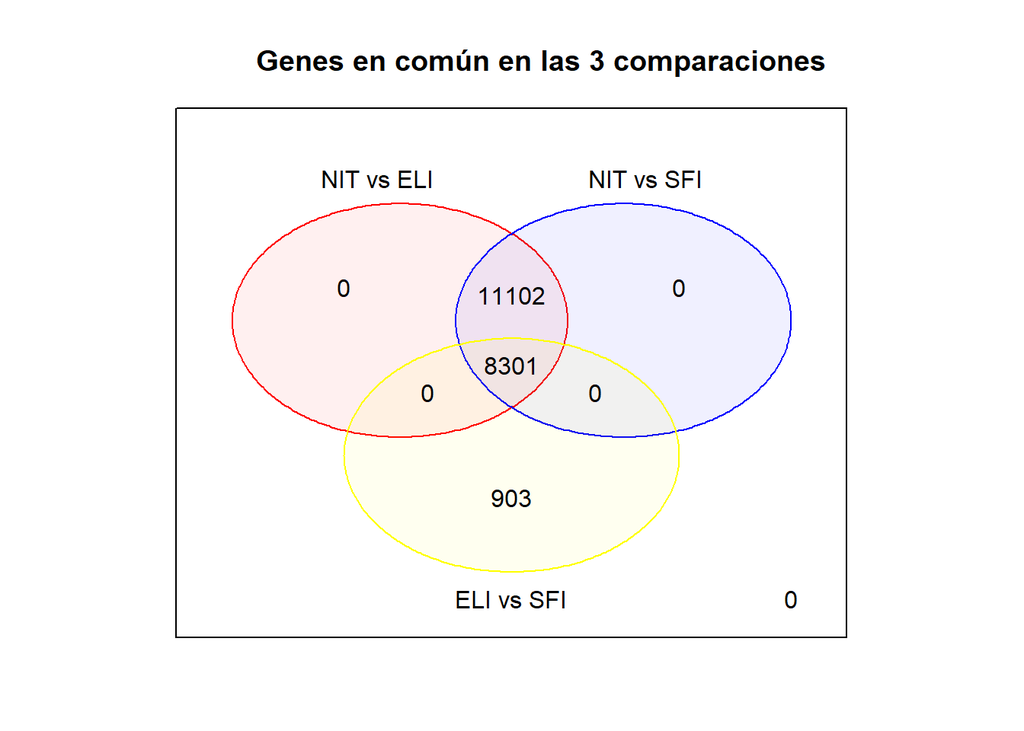

El Diagrama de Venn nos muestra los genes comunes entre las 3 comparaciones. Un total de 8301

#### 6. Análisis de significación biológica (“Gene Enrichment Analysis”)

Utilizamos el paquete ‘ClusterProfiler’ para el análisis de significación biológica. Lo haremos desde 2 perspectivas: por un lado con el workflow de la referencia (3) de Guangchuang Yu. Y por otro lado, con el pathway de ReactomePA adaptado a ClusterProfiler.

#### ClusterProfiler según referencia (3)

#### NIT vs ELI

|  | ID | Description | GeneRatio | BgRatio | pvalue | p.adjust | qvalue | geneID | Count |
| --- | --- | --- | --- | --- | --- | --- | --- | --- | --- |
| GO:0098793 | GO:0098793 | presynapse | 487/17653 | 491/19717 | 6.818448e-19 | 5.222931e-16 | 2.935521e-16 | 5579/5368/23157/3738/5023/8938/9143/5027/8514/594855/10590/1…… | 487 |
| GO:0098978 | GO:0098978 | glutamatergic synapse | 349/17653 | 349/19717 | 1.207379e-17 | 4.624260e-15 | 2.599042e-15 | 814/11151/2185/3738/7074/5023/135/10636/7143/8787/5800/8766/…… | 349 |
| GO:0097060 | GO:0097060 | synaptic membrane | 428/17653 | 432/19717 | 3.266557e-16 | 6.666000e-14 | 3.746591e-14 | 3738/7074/5023/594855/440829/135/10636/8787/5800/27185/38661…… | 428 |
| GO:0043025 | GO:0043025 | neuronal cell body | 490/17653 | 497/19717 | 3.751104e-16 | 6.666000e-14 | 3.746591e-14 | 653361/3676/5368/3783/1269/30009/57471/57699/2185/7074/1233/…… | 490 |
| GO:0005925 | GO:0005925 | focal adhesion | 402/17653 | 405/19717 | 4.351175e-16 | 6.666000e-14 | 3.746591e-14 | 5788/64098/3676/5880/3695/5244/51466/2185/3936/9404/4868/966…… | 402 |
| GO:0005759 | GO:0005759 | mitochondrial matrix | 463/17653 | 469/19717 | 7.383140e-16 | 9.425809e-14 | 5.297727e-14 | 7015/5163/10667/844/28957/2235/11232/3028/5091/8803/2936/113…… | 463 |

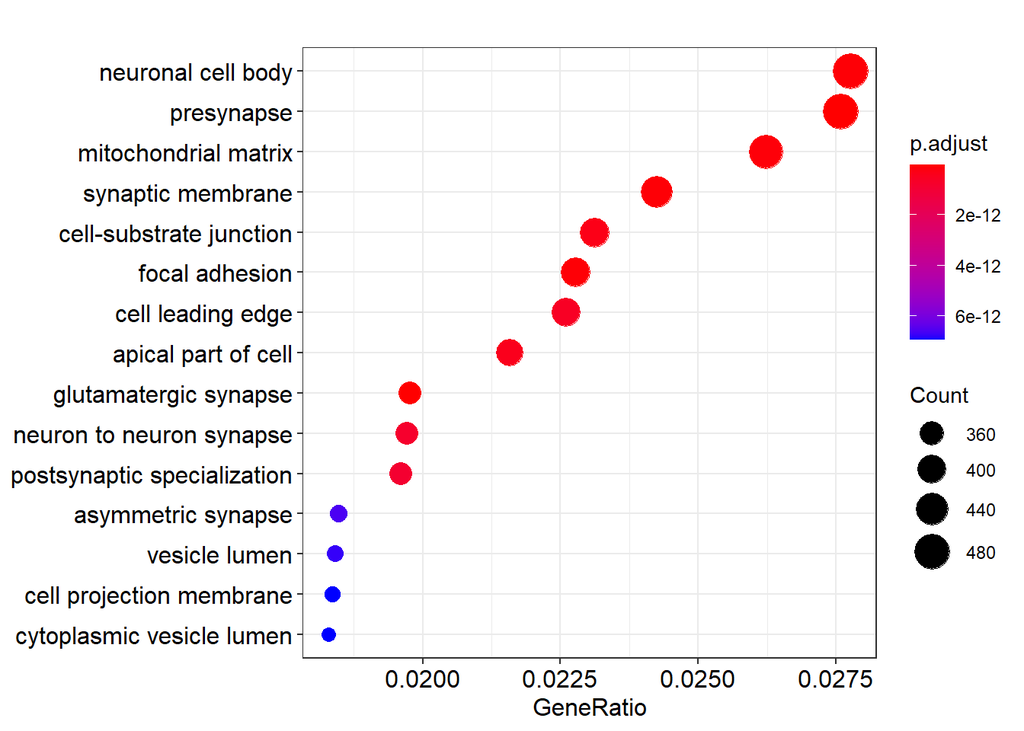

#### NIT vs ELI con los datos significativos

|  | ID | Description | GeneRatio | BgRatio | pvalue | p.adjust | qvalue | geneID | Count |
| --- | --- | --- | --- | --- | --- | --- | --- | --- | --- |
| GO:0005774 | GO:0005774 | vacuolar membrane | 182/5274 | 412/19717 | 1.115544e-14 | 8.522758e-12 | 6.200077e-12 | 3112/326624/4033/9725/4948/80183/128338/3134/55652/302/37439…… | 182 |
| GO:0098852 | GO:0098852 | lytic vacuole membrane | 161/5274 | 355/19717 | 2.472360e-14 | 9.444417e-12 | 6.870560e-12 | 3112/326624/4033/9725/4948/128338/3134/55652/302/374395/1203…… | 161 |
| GO:0005765 | GO:0005765 | lysosomal membrane | 160/5274 | 354/19717 | 4.265344e-14 | 1.086241e-11 | 7.902112e-12 | 3112/326624/4033/9725/4948/128338/3134/55652/302/374395/1203…… | 160 |
| GO:0030667 | GO:0030667 | secretory granule membrane | 135/5274 | 298/19717 | 3.338066e-12 | 5.610022e-10 | 4.081140e-10 | 3683/326624/6402/5788/963/11322/3687/4033/84329/79930/5023/8…… | 135 |
| GO:0010008 | GO:0010008 | endosome membrane | 197/5274 | 479/19717 | 3.671480e-12 | 5.610022e-10 | 4.081140e-10 | 9744/3112/124460/255231/911/84174/8938/926/4948/29887/4689/8…… | 197 |
| GO:0098857 | GO:0098857 | membrane microdomain | 141/5274 | 316/19717 | 4.460296e-12 | 5.679443e-10 | 4.131643e-10 | 84433/3932/931/962/7535/930/5788/695/973/3635/914/8631/330/1…… | 141 |

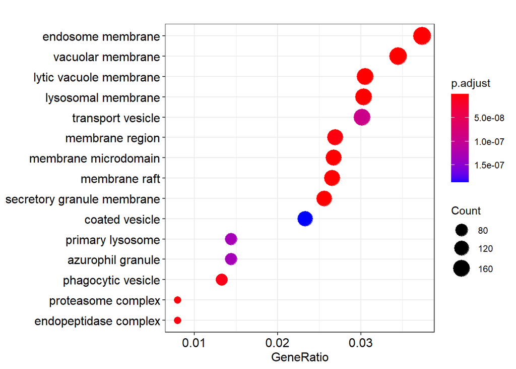

#### NIT vs SFI

|  | ID | Description | GeneRatio | BgRatio | pvalue | p.adjust | qvalue | geneID | Count |
| --- | --- | --- | --- | --- | --- | --- | --- | --- | --- |
| GO:0098793 | GO:0098793 | presynapse | 487/17653 | 491/19717 | 6.818448e-19 | 5.222931e-16 | 2.935521e-16 | 5023/79772/143425/3738/5142/5582/4311/23767/10590/1006/5368/…… | 487 |
| GO:0098978 | GO:0098978 | glutamatergic synapse | 349/17653 | 349/19717 | 1.207379e-17 | 4.624260e-15 | 2.599042e-15 | 5023/3738/23767/1006/56850/1020/55737/64101/10718/3337/999/1…… | 349 |
| GO:0097060 | GO:0097060 | synaptic membrane | 428/17653 | 432/19717 | 3.266557e-16 | 6.666000e-14 | 3.746591e-14 | 5023/3738/5582/7779/23767/2570/1006/55906/1630/1020/2912/641…… | 428 |
| GO:0043025 | GO:0043025 | neuronal cell body | 490/17653 | 497/19717 | 3.751104e-16 | 6.666000e-14 | 3.746591e-14 | 8874/3676/4311/1233/10382/3065/57125/25828/5368/7043/79791/2…… | 490 |
| GO:0005925 | GO:0005925 | focal adhesion | 402/17653 | 405/19717 | 4.351175e-16 | 6.666000e-14 | 3.746591e-14 | 57514/5788/8874/3676/4311/23767/3304/9351/3371/1803/847/1466…… | 402 |
| GO:0005759 | GO:0005759 | mitochondrial matrix | 463/17653 | 469/19717 | 7.383140e-16 | 9.425809e-14 | 5.297727e-14 | 92483/6648/9801/5163/65080/84274/54931/51642/55006/10667/686…… | 463 |

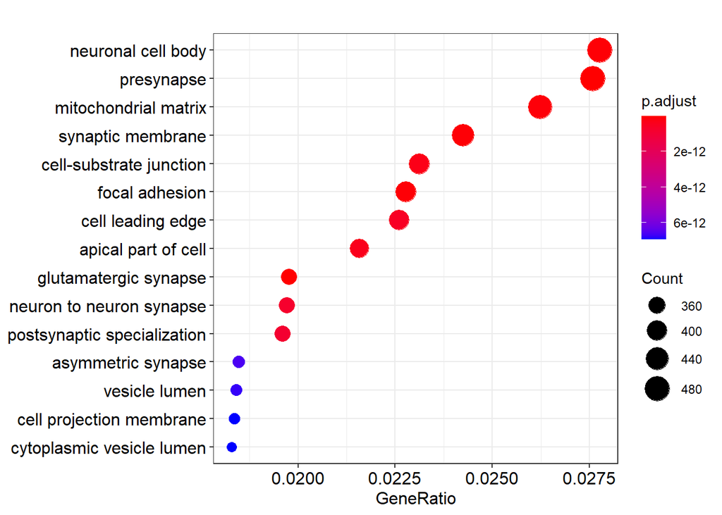

#### NIT vs SFI con los datos significativos

|  | ID | Description | GeneRatio | BgRatio | pvalue | p.adjust | qvalue | geneID | Count |
| --- | --- | --- | --- | --- | --- | --- | --- | --- | --- |
| GO:0009897 | GO:0009897 | external side of plasma membrane | 39/857 | 393/19717 | 1.479241e-06 | 0.000798790 | 0.0007769907 | 4283/100423062/931/973/5023/1493/940/3561/29851/10859/3762/3…… | 39 |
| GO:0005759 | GO:0005759 | mitochondrial matrix | 42/857 | 469/19717 | 8.098322e-06 | 0.002186547 | 0.0021268751 | 92483/6648/9801/5163/65080/84274/54931/51642/55006/10667/686…… | 42 |

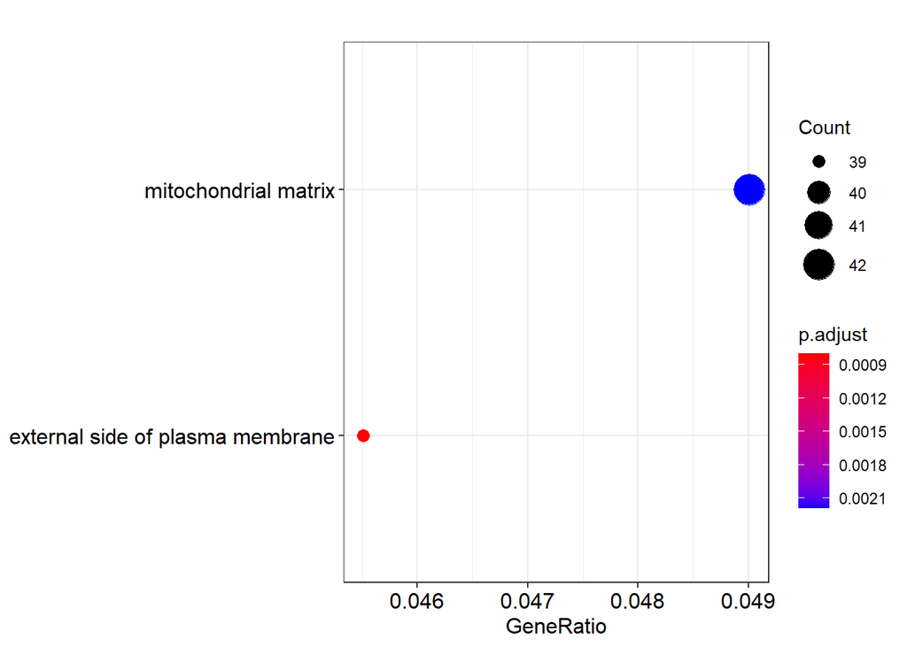

#### ELI vs SFI

|  | ID | Description | GeneRatio | BgRatio | pvalue | p.adjust | qvalue | geneID | Count |
| --- | --- | --- | --- | --- | --- | --- | --- | --- | --- |
| GO:0150034 | GO:0150034 | distal axon | 283/17677 | 296/21659 | 4.632806e-13 | 3.413871e-10 | 2.295754e-10 | ENSG00000166501/ENSG00000120899/ENSG00000125354/ENSG00000151…… | 283 |
| GO:0043235 | GO:0043235 | receptor complex | 392/17677 | 419/21659 | 8.502792e-13 | 3.413871e-10 | 2.295754e-10 | ENSG00000007312/ENSG00000117322/ENSG00000111679/ENSG00000096…… | 392 |
| GO:0031252 | GO:0031252 | cell leading edge | 400/17677 | 430/21659 | 6.022935e-12 | 1.530809e-09 | 1.029436e-09 | ENSG00000161929/ENSG00000068831/ENSG00000102879/ENSG00000111…… | 400 |
| GO:0005938 | GO:0005938 | cell cortex | 307/17677 | 325/21659 | 7.625450e-12 | 1.530809e-09 | 1.029436e-09 | ENSG00000102879/ENSG00000110934/ENSG00000120899/ENSG00000070…… | 307 |
| GO:0099568 | GO:0099568 | cytoplasmic region | 248/17677 | 260/21659 | 3.127931e-11 | 5.023457e-09 | 3.378165e-09 | ENSG00000117724/ENSG00000163093/ENSG00000090889/ENSG00000198…… | 248 |
| GO:0098978 | GO:0098978 | glutamatergic synapse | 349/17677 | 375/21659 | 1.152573e-10 | 1.324241e-08 | 8.905235e-09 | ENSG00000102879/ENSG00000152495/ENSG00000120899/ENSG00000151…… | 349 |

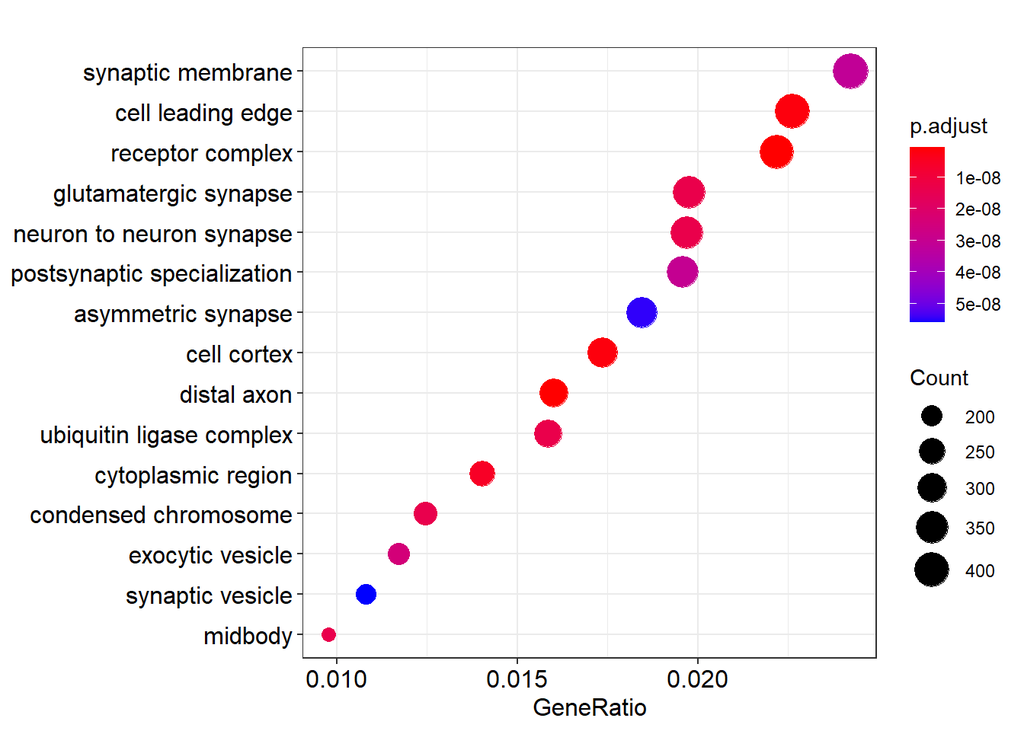

#### ELI vs SFI con los datos significativos

|  | ID | Description | GeneRatio | BgRatio | pvalue | p.adjust | qvalue | geneID | Count |
| --- | --- | --- | --- | --- | --- | --- | --- | --- | --- |
| GO:0009897 | GO:0009897 | external side of plasma membrane | 116/2398 | 429/21659 | 1.748115e-20 | 1.232421e-17 | 1.034148e-17 | ENSG00000007312/ENSG00000112486/ENSG00000104921/ENSG00000096…… | 116 |
| GO:0000779 | GO:0000779 | condensed chromosome, centromeric region | 46/2398 | 127/21659 | 7.623932e-14 | 2.687436e-11 | 2.255079e-11 | ENSG00000123219/ENSG00000117724/ENSG00000080986/ENSG00000178…… | 46 |
| GO:0000775 | GO:0000775 | chromosome, centromeric region | 62/2398 | 209/21659 | 1.624130e-13 | 3.816704e-11 | 3.202669e-11 | ENSG00000123219/ENSG00000117724/ENSG00000080986/ENSG00000178…… | 62 |
| GO:0098802 | GO:0098802 | plasma membrane signaling receptor complex | 59/2398 | 198/21659 | 5.049480e-13 | 8.899708e-11 | 7.467915e-11 | ENSG00000007312/ENSG00000111679/ENSG00000096996/ENSG00000156…… | 59 |
| GO:0000776 | GO:0000776 | kinetochore | 48/2398 | 145/21659 | 1.061955e-12 | 1.497356e-10 | 1.256460e-10 | ENSG00000123219/ENSG00000117724/ENSG00000080986/ENSG00000178…… | 48 |
| GO:0098687 | GO:0098687 | chromosomal region | 91/2398 | 385/21659 | 1.352512e-12 | 1.589202e-10 | 1.333530e-10 | ENSG00000123219/ENSG00000117724/ENSG00000080986/ENSG00000178…… | 91 |

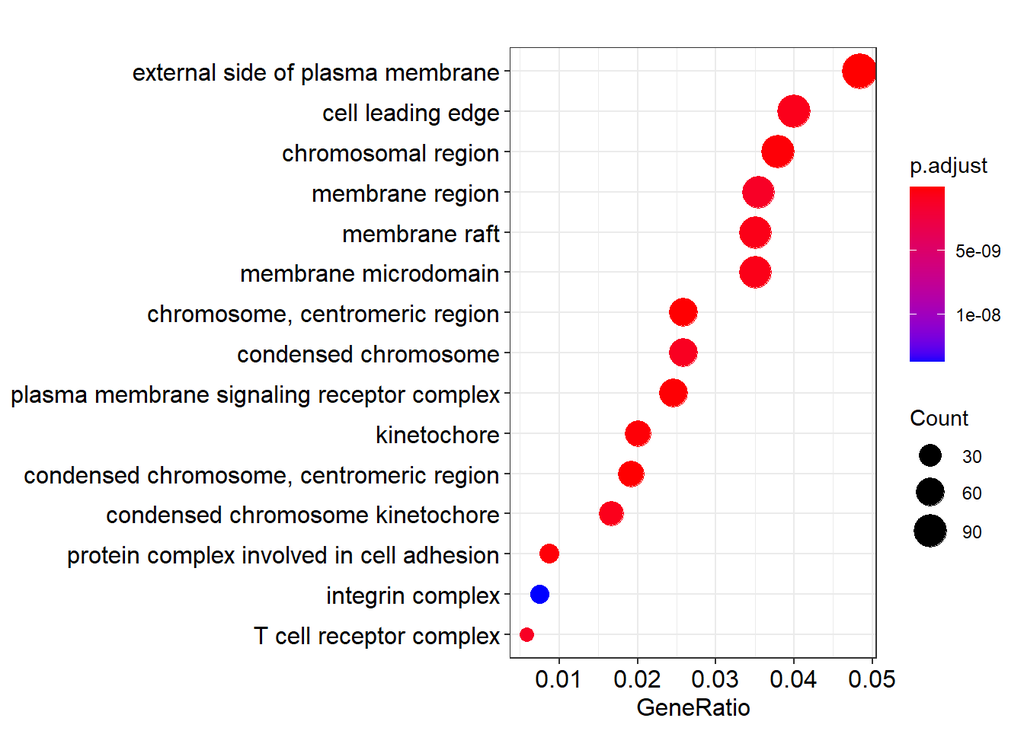

Preparamos lista de genes analizados

```
## NIT_vs_ELI NIT_vs_SFI ELI_vs_SFI
##       8318       1608       3670
```

```
## Reading KEGG annotation online:
##
## Reading KEGG annotation online:
```

[output not shown]

```
## ##################################
## Comparison:  NIT_vs_SFI
##                ID                                  Description GeneRatio
## hsa05340 hsa05340                     Primary immunodeficiency    13/396
## hsa04672 hsa04672 Intestinal immune network for IgA production    10/396
## hsa04640 hsa04640                   Hematopoietic cell lineage    15/396
## hsa04660 hsa04660            T cell receptor signaling pathway    15/396
## hsa04146 hsa04146                                   Peroxisome    13/396
## hsa04658 hsa04658             Th1 and Th2 cell differentiation    13/396
##           BgRatio       pvalue     p.adjust       qvalue
## hsa05340  37/7984 1.085716e-08 3.224577e-06 3.165720e-06
## hsa04672  47/7984 7.988542e-05 8.558234e-03 8.402023e-03
## hsa04640  98/7984 8.644680e-05 8.558234e-03 8.402023e-03
## hsa04660 103/7984 1.539506e-04 1.143083e-02 1.122219e-02
## hsa04146  83/7984 2.007277e-04 1.192322e-02 1.170559e-02
## hsa04658  92/7984 5.651121e-04 2.797305e-02 2.746247e-02
##                                                                              geneID
## hsa05340          973/7374/3561/29851/115650/5788/915/7535/6890/930/23495/3932/3718
## hsa04672                        608/940/3112/29851/115650/7852/3676/23495/9020/8174
## hsa04640         931/3112/1440/924/3568/3676/4311/921/915/930/960/951/952/1441/3566
## hsa04660 1493/10125/3458/940/29851/3702/5788/915/7535/84433/9402/919/3932/9020/3937
## hsa04146         54677/5193/6648/1891/3417/847/5052/10478/23600/8800/6647/8504/3295
## hsa04658            3458/3561/3112/915/6775/7535/3560/6772/919/3932/30009/3718/3566
##          Count
## hsa05340    13
## hsa04672    10
## hsa04640    15
## hsa04660    15
## hsa04146    13
## hsa04658    13
```

[output not shown]

#### NIT vs ELI

Tabla NIT_vs_ELI

| ID | Description | GeneRatio | BgRatio | pvalue | p.adjust | qvalue | geneID | Count |
| --- | --- | --- | --- | --- | --- | --- | --- | --- |
| hsa03050 | Proteasome | 37/2370 | 46/7984 | 1.33169618139426e-12 | 4.30137866590346e-10 | 3.36428508983813e-10 | 5682/5702/3458/5707/5693/5700/5704/5694/5708/10213/5696/5701/10197/5684/5687/5690/143471/5685/5714/5692/5683/5698/5705/5713/5710/51371/5709/5717/5719/9491/5715/5689/5686/5688/5695/5699/9861 | 37 |
| hsa05340 | Primary immunodeficiency | 30/2370 | 37/7984 | 1.30217113758605e-10 | 2.10300638720148e-08 | 1.64484775274028e-08 | 3561/3932/915/7535/930/5788/916/29851/695/973/3718/115650/959/4261/926/57379/3575/326/925/23495/6890/3543/7374/6891/920/29760/958/100/927/5993 | 30 |
| hsa05012 | Parkinson disease | 117/2370 | 249/7984 | 3.82016457986877e-09 | 4.11304386432538e-07 | 3.21698069883686e-07 | 135/7345/5682/10383/3309/5702/5707/4702/84790/5693/5700/5704…… | 117 |
| hsa05330 | Allograft rejection | 28/2370 | 37/7984 | 9.37684061322095e-09 | 6.27962242520048e-07 | 4.91155086214149e-07 | 3112/940/356/959/7124/3134/3115/3458/3558/3111/3113/3108/3117/3122/942/3119/3106/355/941/3592/5551/3105/3109/958/3123/3593/3107/3586 | 28 |
| hsa05010 | Alzheimer disease | 159/2370 | 367/7984 | 9.72077774798836e-09 | 6.27962242520048e-07 | 4.91155086214149e-07 | 5330/80326/5293/489/7124/841/7471/51384/778/5682/10383/5702/…… | 159 |
| hsa05416 | Viral myocarditis | 38/2370 | 59/7984 | 3.2717420650491e-08 | 1.75577715875078e-06 | 1.37326549812673e-06 | 3683/3112/5880/940/959/841/3134/3115/1605/3111/3113/3108/25/3117/5879/3122/3689/942/8672/3119/1981/3106/836/941/4625/5551/3105/284217/3109/958/6444/1525/3123/637/3107/54205/2534/857 | 38 |

#### NIT vs SFI

Tabla NIT_vs_SFI

| ID | Description | GeneRatio | BgRatio | pvalue | p.adjust | qvalue | geneID | Count |
| --- | --- | --- | --- | --- | --- | --- | --- | --- |
| hsa05340 | Primary immunodeficiency | 13/396 | 37/7984 | 1.08571630893433e-08 | 3.22457743753495e-06 | 3.16572018499799e-06 | 973/7374/3561/29851/115650/5788/915/7535/6890/930/23495/3932/3718 | 13 |
| hsa04672 | Intestinal immune network for IgA production | 10/396 | 47/7984 | 7.98854193337924e-05 | 0.00855823353719393 | 0.0084020226468287 | 608/940/3112/29851/115650/7852/3676/23495/9020/8174 | 10 |
| hsa04640 | Hematopoietic cell lineage | 15/396 | 98/7984 | 8.64468034059993e-05 | 0.00855823353719393 | 0.0084020226468287 | 931/3112/1440/924/3568/3676/4311/921/915/930/960/951/952/1441/3566 | 15 |
| hsa04660 | T cell receptor signaling pathway | 15/396 | 103/7984 | 0.000153950578032668 | 0.0114308304189256 | 0.0112221868723814 | 1493/10125/3458/940/29851/3702/5788/915/7535/84433/9402/919/3932/9020/3937 | 15 |
| hsa04146 | Peroxisome | 13/396 | 83/7984 | 0.00020072765592283 | 0.0119232227618161 | 0.0117055917243419 | 54677/5193/6648/1891/3417/847/5052/10478/23600/8800/6647/8504/3295 | 13 |
| hsa04658 | Th1 and Th2 cell differentiation | 13/396 | 92/7984 | 0.000565112106842106 | 0.0279730492886842 | 0.0274624655430287 | 3458/3561/3112/915/6775/7535/3560/6772/919/3932/30009/3718/3566 | 13 |

Tabla ELI_vs_SFI

| ID | Description | GeneRatio | BgRatio | pvalue | p.adjust | qvalue | geneID | Count |
| --- | --- | --- | --- | --- | --- | --- | --- | --- |
| hsa04640 | Hematopoietic cell lineage | 46/1084 | 98/7984 | 9.44912362283061e-16 | 2.9953721884373e-13 | 2.37720057458581e-13 | 1380/2208/951/916/917/3112/911/915/930/914/933/1378/1440/367…… | 46 |
| hsa05340 | Primary immunodeficiency | 23/1084 | 37/7984 | 8.35913200088488e-12 | 1.32492242214025e-09 | 1.05149081484815e-09 | 3932/916/695/57379/3561/7535/915/930/959/3718/5788/3575/4261/926/29851/920/64421/29760/925/115650/5993/973/326 | 23 |
| hsa04514 | Cell adhesion molecules (CAMs) | 50/1084 | 147/7984 | 1.60355126228152e-10 | 1.69441916714414e-08 | 1.34473246205362e-08 | 6402/3385/3683/6693/3695/3112/5133/914/933/5817/923/959/2414…… | 50 |
| hsa04659 | Th17 cell differentiation | 37/1084 | 107/7984 | 2.39023985222337e-08 | 1.89426508288702e-06 | 1.50333506495101e-06 | 3932/3594/916/917/50615/9466/3560/919/3561/3112/7535/915/3718/27040/3091/149233/3109/6774/3556/30009/50943/920/3662/4794/3569/3553/3558/51561/2625/3551/3111/3559/3554/3570/3115/3119/5914 | 37 |
| hsa04670 | Leukocyte transendothelial migration | 37/1084 | 113/7984 | 1.21342409863878e-07 | 7.69310878536984e-06 | 6.10543914894037e-06 | 5579/653361/2185/3683/7294/5880/5293/5336/7409/399/81/1495/1500/6494/1536/24146/3676/9564/5829/3702/3689/3688/4689/7122/3684/7414/4478/7852/5879/5781/4633/90952/87/103910/1366/9075/387 | 37 |
| hsa04810 | Regulation of actin cytoskeleton | 57/1084 | 213/7984 | 1.78780799852586e-07 | 8.62440550239862e-06 | 6.84453898413837e-06 | 3681/3683/5880/3695/5293/7409/7074/623/81/9138/5305/3676/368…… | 57 |

Los datos al completo los encotramos almacenados en los respectivos archivos .csv para cada comparación.

## Resultados

Obtenemos resultados significativos al realizar el análisis con ambos procedimientos y según la comparación entre grupos.

El Gene Set Enrichment Analysis mostró genes que se expresan de manera diferencial según grupo y comparación.

### Grupo NIT vs Grupo ELI

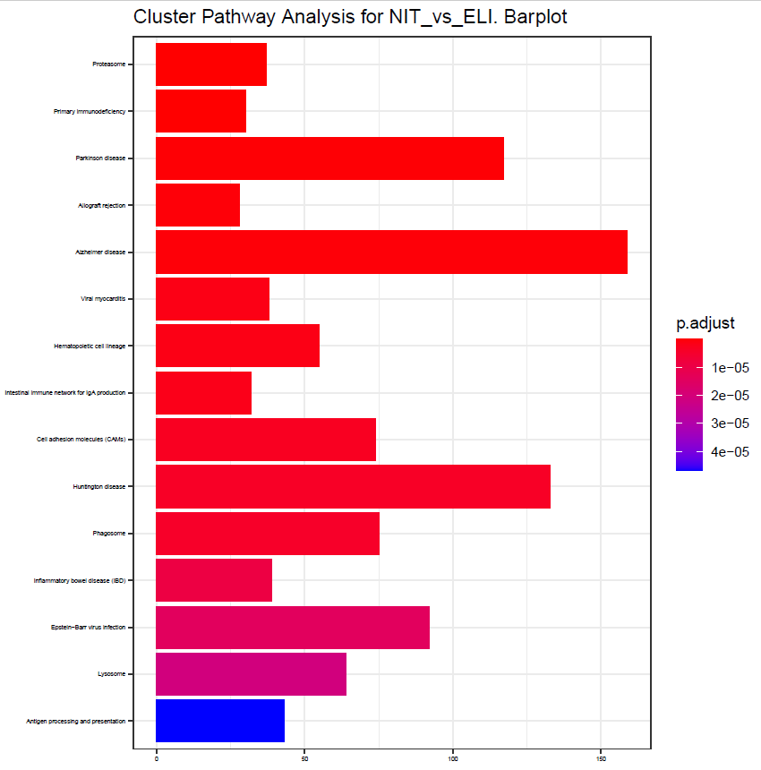

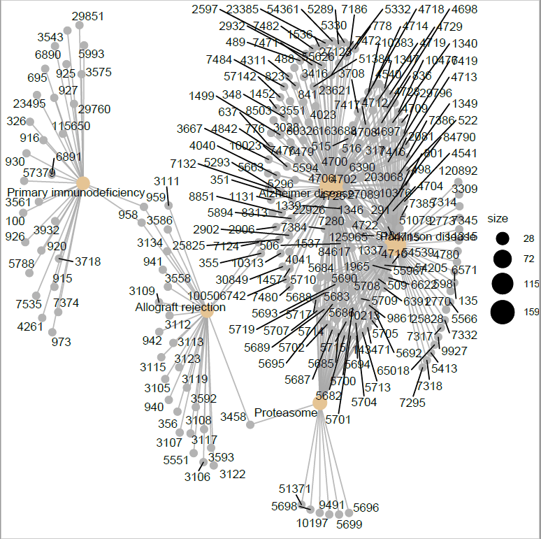

### Grupo NIT vs Grupo SFI

Entre el grupo NIT y SFI encontramos genes expresados de forma diferencial. Con especial atención a aquellos genes relacionados con el sistema inmune y su respuesta humoral.

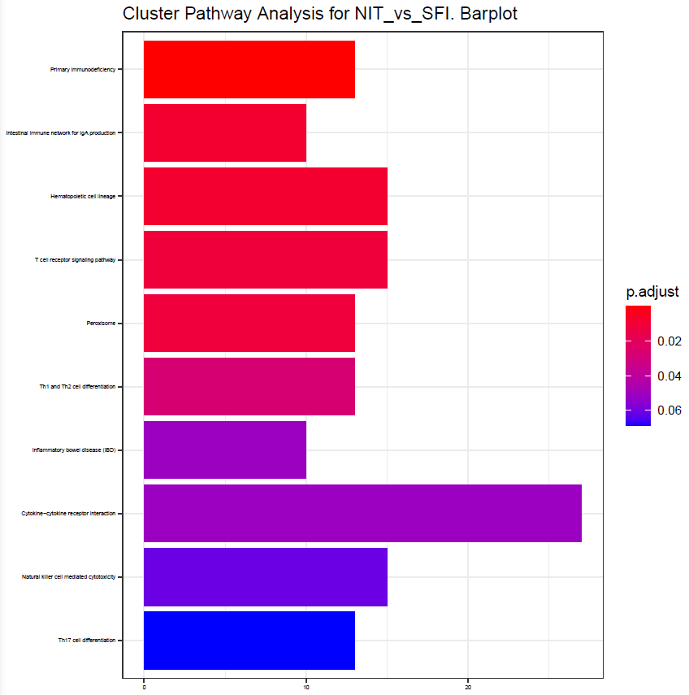

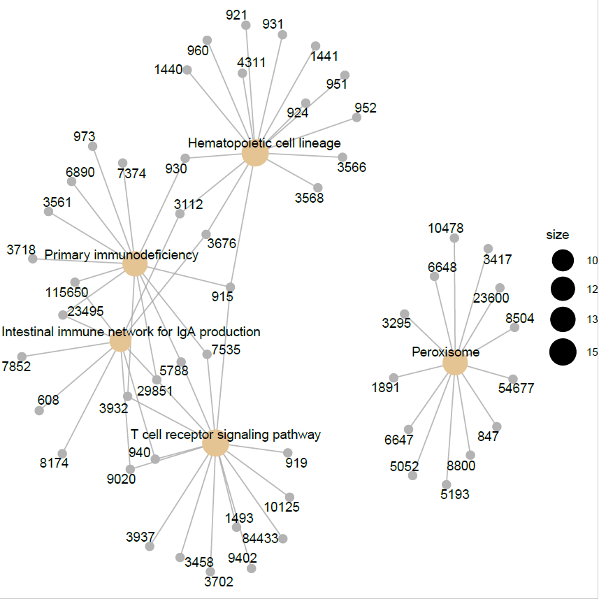

### Grupo ELI vs Grupo SFI

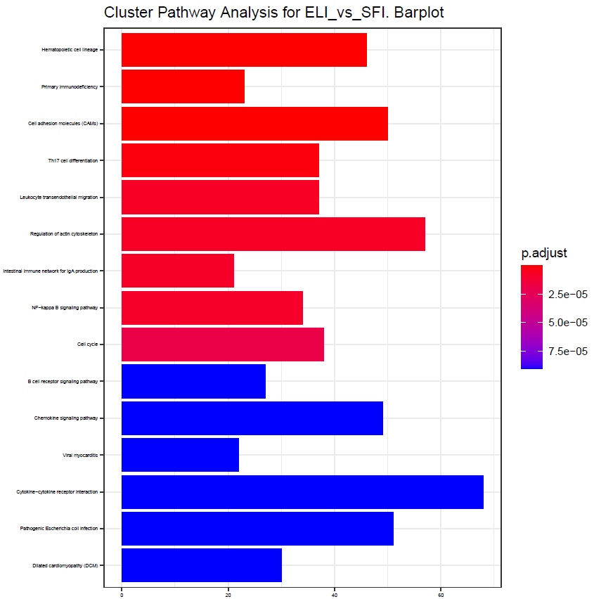

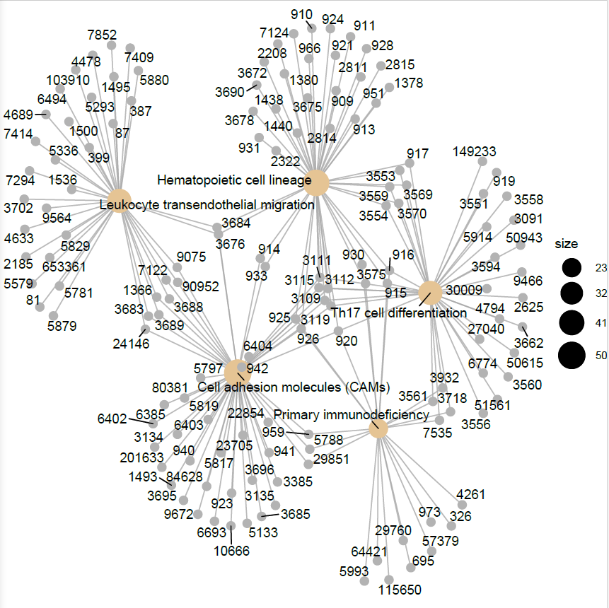

## Discusión

El análisis de los datos de expresión de RNA es una herramienta útil y poderosa.

Mediante el análisis con R y los paquetes de BioConductor, se puede obtener y realizar distintos procesos. Desde el filtraje de los datos, transformación de estos, visualización en gráficos y su significación biológica, entre otras. Permitiendo realizar un completo análisis de los datos.

No obstante, hay algunas limitaciones vistas durante este análisis.

Por ejemplo, factores técnicos como el elevado NA en el mapeado al realizar la anotación aunque no ha sido un impedimento para el proceso. También el conteo bajo en algunos genes.

De todas maneras, el análisis se puede concluir como positivo. Ayudando a confirmar hipótesis iniciales acerca de qué diferencias de expresión se pueden encontrar en distintos téjidos según infiltración tiroidea y que genes tiene expresados.

## Apéndice

El código R usado en este documento R Markdown:

```r
## ----setup, include=FALSE---------------------
knitr::opts_chunk$set(echo = TRUE)


## ----4.1, include=FALSE-----------------------
setwd(".")
dir.create("data")
dir.create("results")


## ----include=FALSE----------------------------
library(knitr)
library(readr)
library(colorspace)
library(gplots)
library(ggplot2)
library(DESeq2)
library(AnnotationDbi)
library(org.Hs.eg.db)
library(hugene21sttranscriptcluster.db)
library(clusterProfiler)
library(dplyr)
library(limma)
library(hexbin)
library(pheatmap)
library(RColorBrewer)


## ----include=FALSE----------------------------
counts <- read_delim("C:/Users/rubenuoc/Desktop/UOC/MO157/PEC2/PEC_02/data/counts.csv",
                     ";", escape_double = FALSE, trim_ws = TRUE)


targets <- read_csv("C:/Users/rubenuoc/Desktop/UOC/MO157/PEC2/PEC_02/data/targets.csv")



## ----include=FALSE----------------------------
set.seed(280520)

targets_10_g <- lapply(split(targets, targets$Grupo_analisis),
                       function(subdf) subdf[sample(1:nrow(subdf), 10),])


targets_10_g <- do.call('rbind', targets_10_g)



## ----echo=FALSE-------------------------------
head(targets_10_g)


## ----include=FALSE----------------------------
df <- counts[, targets_10_g$Sample_Name]

# Para que podamos realizar con mayor falicidad el análisis posterior, cambiaremos el nombre de cada filas: 1, 2, 3, etc por el nombre de la columna X1 del archivo 'counts'.

# Añadimos la columna X1 a nuestro dataframe

df <- cbind(df, X1 = counts$X1)


# Cambiamos orden para tenerla primera y poder cambiar el

df <- df[, c(31, 1:30)]

countdata <- df[,-1]
rownames(countdata) <- df[,1]


## ----include=FALSE----------------------------
dds <- DESeqDataSetFromMatrix(countData = countdata, colData = targets_10_g, design = ~Group)



## ----echo=FALSE-------------------------------
nrow(dds)

dds <- dds[ rowSums(counts(dds)) > 1, ]
nrow(dds)


## ----echo=FALSE-------------------------------
vsd <- vst(dds, blind = FALSE) # blind = FALSE para evitar que las variables en el diseño del objeto (Group) interfieran en la varianza media esperada
head(assay(vsd), 3)


## ----echo=FALSE-------------------------------
colData(vsd)


## ----echo=FALSE-------------------------------
rld <- rlog(dds, blind = FALSE)
head(assay(rld), 3)


## ----include=FALSE----------------------------
dds <- estimateSizeFactors(dds)

df <- bind_rows(
  as_data_frame(log2(counts(dds, normalized=TRUE)[, 1:2]+1)) %>%
         mutate(transformation = "log2(x + 1)"),
  as_data_frame(assay(vsd)[, 1:2]) %>% mutate(transformation = "vst"),
  as_data_frame(assay(rld)[, 1:2]) %>% mutate(transformation = "rlog"))


## ----echo=FALSE-------------------------------
colnames(df)[1:2] <- c("x", "y")

ggplot(df, aes(x = x, y = y)) + geom_hex(bins = 80) +
  coord_fixed() + facet_grid( . ~ transformation)


## ----include=FALSE----------------------------
sampleDists <- dist(t(assay(vsd)))
sampleDists


## ----echo=FALSE-------------------------------

sampleDistMatrix <- as.matrix( sampleDists )
rownames(sampleDistMatrix) <- paste( vsd$dex, vsd$cell, sep = " - " )
colnames(sampleDistMatrix) <- NULL
colors <- colorRampPalette( rev(brewer.pal(9, "Blues")) )(255)
pheatmap(sampleDistMatrix,
         clustering_distance_rows = sampleDists,
         clustering_distance_cols = sampleDists,
         col = colors)


## ----echo=FALSE-------------------------------
plotPCA(vsd, intgroup = c("Group"))


## ----include=FALSE----------------------------
dds <- DESeq(dds)


## ----echo=FALSE-------------------------------
# Realizamos las distintas comparaciones usando 'constrast' para cada grupo, con su respectivo factor: 'Group' en primer lugar, y los 2 grupos a comparar.

# NIT vs ELI

res_NIT_vs_ELI <- results(dds, contrast = c("Group", "NIT", "ELI"))

NIT_vs_ELI_rownames <- row.names(res_NIT_vs_ELI)

summary(res_NIT_vs_ELI)



## ----echo=FALSE-------------------------------
# NIT vs SFI

res_NIT_vs_SFI <- results(dds, contrast = c("Group", "NIT", "SFI"))

NIT_vs_SFI_rownames <- row.names(res_NIT_vs_SFI)

summary(res_NIT_vs_SFI)


## ----echo=FALSE-------------------------------
# ELI vs SFI

res_ELI_vs_SFI <- results(dds, contrast = c("Group", "ELI", "SFI"))

ELI_vs_SFI_rownames <- row.names(res_ELI_vs_SFI)

summary(res_ELI_vs_SFI)


## ----include=FALSE----------------------------
sum(res_NIT_vs_ELI$padj < 0.1, na.rm=TRUE)

sum(res_NIT_vs_SFI$padj < 0.1, na.rm=TRUE)

sum(res_ELI_vs_SFI$padj < 0.1, na.rm=TRUE)


## ----include=FALSE----------------------------
res_NIT_vs_ELI_Sig <- subset(res_NIT_vs_ELI, padj < 0.1)

res_NIT_vs_SFI_Sig <- subset(res_NIT_vs_SFI, padj < 0.1)

res_ELI_vs_SFI_Sig <- subset(res_ELI_vs_SFI, padj < 0.1)


## ----echo=FALSE-------------------------------
head(res_NIT_vs_ELI_Sig[ order(res_NIT_vs_ELI_Sig$log2FoldChange), ])

head(res_NIT_vs_SFI_Sig[ order(res_NIT_vs_SFI_Sig$log2FoldChange), ])

head(res_ELI_vs_SFI_Sig[ order(res_ELI_vs_SFI_Sig$log2FoldChange), ])


## ----echo=FALSE-------------------------------
head(res_NIT_vs_ELI_Sig[ order(res_NIT_vs_ELI_Sig$log2FoldChange, decreasing = TRUE), ])

head(res_NIT_vs_SFI_Sig[ order(res_NIT_vs_SFI_Sig$log2FoldChange, decreasing = TRUE), ])

head(res_ELI_vs_SFI_Sig[ order(res_ELI_vs_SFI_Sig$log2FoldChange, decreasing = TRUE), ])


## ----include=FALSE----------------------------
columns(org.Hs.eg.db)


## ----echo=FALSE-------------------------------
# NIT vs ELI Sig

tmp_NIT_vs_ELI_Sig=gsub("\\..*","",row.names(res_NIT_vs_ELI_Sig)) # borrar '.' de ENSEMBL

res_NIT_vs_ELI_Sig$symbol <- mapIds(org.Hs.eg.db,
                     keys=tmp_NIT_vs_ELI_Sig,
                     column="SYMBOL",
                     keytype="ENSEMBL",
                     multiVals="first")

res_NIT_vs_ELI_Sig$entrez <- mapIds(org.Hs.eg.db,
                     keys=tmp_NIT_vs_ELI_Sig,
                     column="ENTREZID",
                     keytype="ENSEMBL",
                     multiVals="first")

res_NIT_vs_ELI_Sig_Ordered <- res_NIT_vs_ELI_Sig[order(res_NIT_vs_ELI_Sig$pvalue),]
```

```r
head(res_NIT_vs_ELI_Sig_Ordered)

# NIT vs SFI Sig

tmp_NIT_vs_SFI_Sig=gsub("\\..*","",row.names(res_NIT_vs_SFI_Sig)) # borrar '.' de ENSEMBL

res_NIT_vs_SFI_Sig$symbol <- mapIds(org.Hs.eg.db,
                     keys=tmp_NIT_vs_SFI_Sig,
                     column="SYMBOL",
                     keytype="ENSEMBL",
                     multiVals="first")

res_NIT_vs_SFI_Sig$entrez <- mapIds(org.Hs.eg.db,
                     keys=tmp_NIT_vs_SFI_Sig,
                     column="ENTREZID",
                     keytype="ENSEMBL",
                     multiVals="first")

res_NIT_vs_SFI_Sig_Ordered <- res_NIT_vs_SFI_Sig[order(res_NIT_vs_SFI_Sig$pvalue),]

head(res_NIT_vs_SFI_Sig_Ordered)

# ELI vs SFI Sig

tmp_ELI_vs_SFI_Sig=gsub("\\..*","",row.names(res_ELI_vs_SFI_Sig)) # borrar '.' de ENSEMBL

res_ELI_vs_SFI_Sig$symbol <- mapIds(org.Hs.eg.db,
                     keys=tmp_ELI_vs_SFI_Sig,
                     column="SYMBOL",
                     keytype="ENSEMBL",
                     multiVals="first")

res_ELI_vs_SFI_Sig$entrez <- mapIds(org.Hs.eg.db,
                     keys=tmp_ELI_vs_SFI_Sig,
                     column="ENTREZID",
                     keytype="ENSEMBL",
                     multiVals="first")

res_ELI_vs_SFI_Sig_Ordered <- res_ELI_vs_SFI_Sig[order(res_ELI_vs_SFI_Sig$pvalue),]

head(res_ELI_vs_SFI_Sig_Ordered)


## ----echo=FALSE-------------------------------
# Para obtener las keys

# NIT vs ELI

tmp_NIT_vs_ELI=gsub("\\..*","",row.names(res_NIT_vs_ELI)) # borrar '.' de ENSEMBL

res_NIT_vs_ELI$symbol <- mapIds(org.Hs.eg.db,
                     keys=tmp_NIT_vs_ELI,
                     column="SYMBOL",
                     keytype="ENSEMBL",
                     multiVals="first")

res_NIT_vs_ELI$entrez <- mapIds(org.Hs.eg.db,
                     keys=tmp_NIT_vs_ELI,
                     column="ENTREZID",
                     keytype="ENSEMBL",
                     multiVals="first")

res_NIT_vs_ELI_Ordered <- res_NIT_vs_ELI[order(res_NIT_vs_ELI$pvalue),]

head(res_NIT_vs_ELI_Ordered)

# NIT vs SFI

res_NIT_vs_SFI_DF <- as.data.frame(res_NIT_vs_SFI)

tmp_NIT_vs_SFI=gsub("\\..*","",row.names(res_NIT_vs_SFI)) # borrar '.' de ENSEMBL

res_NIT_vs_SFI$symbol <- mapIds(org.Hs.eg.db,
                     keys=tmp_NIT_vs_SFI,
                     column="SYMBOL",
                     keytype="ENSEMBL",
                     multiVals="first")

res_NIT_vs_SFI$entrez <- mapIds(org.Hs.eg.db,
                     keys=tmp_NIT_vs_SFI,
                     column="ENTREZID",
                     keytype="ENSEMBL",
                     multiVals="first")

res_NIT_vs_SFI_Ordered <- res_NIT_vs_SFI[order(res_NIT_vs_SFI$pvalue),]

head(res_NIT_vs_SFI_Ordered)

# ELI vs SFI

res_ELI_vs_SFI_DF <- as.data.frame(res_ELI_vs_SFI)

tmp_ELI_vs_SFI=gsub("\\..*","",row.names(res_ELI_vs_SFI_DF)) # borrar '.' de ENSEMBL

res_ELI_vs_SFI$symbol <- mapIds(org.Hs.eg.db,
                     keys=tmp_ELI_vs_SFI,
                     column="SYMBOL",
                     keytype="ENSEMBL",
                     multiVals="first")

res_ELI_vs_SFI$entrez <- mapIds(org.Hs.eg.db,
                     keys=tmp_ELI_vs_SFI,
                     column="ENTREZID",
                     keytype="ENSEMBL",
                     multiVals="first")

res_ELI_vs_SFI_Ordered <- res_ELI_vs_SFI[order(res_ELI_vs_SFI$pvalue),]

head(res_ELI_vs_SFI_Ordered)



## ----Significativos, include=FALSE------------
# Exportamos los resultados significativos

# NIT_vs_ELI

res_NIT_vs_ELI_Sig_Ordered_DF <- as.data.frame(res_NIT_vs_ELI_Sig_Ordered)

write.csv(res_NIT_vs_ELI_Sig_Ordered, file = "./results/NIT_vs_ELI_Sig.csv")

# NIT_vs_SFI

res_NIT_vs_SFI_Sig_Ordered_DF <- as.data.frame(res_NIT_vs_SFI_Sig_Ordered)

write.csv(res_NIT_vs_SFI_Sig_Ordered, file = "./results/NIT_vs_SFI_Sig.csv")

# ELI_vs_SFI

res_ELI_vs_SFI_Sig_Ordered_DF <- as.data.frame(res_ELI_vs_SFI_Sig_Ordered)

write.csv(res_ELI_vs_SFI_Sig_Ordered, file = "./results/ELI_vs_SFI_Sig.csv")


## ----include=FALSE----------------------------
# Exportamos los resultados

# NIT_vs_ELI

res_NIT_vs_ELI_Ordered_DF <- as.data.frame(res_NIT_vs_ELI_Ordered)

write.csv(res_NIT_vs_ELI_Ordered, file = "./results/NIT_vs_ELI.csv")

# NIT_vs_SFI

res_NIT_vs_SFI_Ordered_DF <- as.data.frame(res_NIT_vs_SFI_Ordered)

write.csv(res_NIT_vs_SFI_Ordered, file = "./results/NIT_vs_SFI.csv")

# ELI_vs_SFI

res_ELI_vs_SFI_Ordered_DF <- as.data.frame(res_ELI_vs_SFI_Ordered)

write.csv(res_ELI_vs_SFI_Ordered, file = "./results/ELI_vs_SFI.csv")



## ----echo=FALSE-------------------------------
# Combinamos las 3 comparaciones para el posterior Diagrama de Venn

comb <- c(rownames(res_NIT_vs_ELI_Sig_Ordered_DF), rownames(res_NIT_vs_ELI_Sig_Ordered_DF), rownames(res_ELI_vs_SFI_Sig_Ordered_DF))

res_NIT_vs_ELI_venn <- comb %in% rownames(res_NIT_vs_ELI_Sig_Ordered_DF)
res_NIT_vs_SFI_venn <- comb %in% rownames(res_NIT_vs_ELI_Sig_Ordered_DF)
res_ELI_vs_SFI_venn <- comb %in% rownames(res_ELI_vs_SFI_Sig_Ordered_DF)

counts_venn <- cbind(res_NIT_vs_ELI_venn, res_NIT_vs_SFI_venn, res_ELI_vs_SFI_venn)

results_venn <- vennCounts(counts_venn)

vennDiagram (results_venn, cex=1, names = c("NIT vs ELI", "NIT vs SFI", "ELI vs SFI"), circle.col = c("red", "blue", "yellow"))

title("Genes en común en las 3 comparaciones")


## ----echo=FALSE-------------------------------
# Con el paquete 'ClusterProfiler'

tmp_NIT_vs_ELI=gsub("\\..*","",row.names(res_NIT_vs_ELI_Ordered_DF)) # borrar '.' de ENSEMBL

ego_NIT_vs_ELI <- enrichGO(gene         = res_NIT_vs_ELI_Ordered_DF$entrez,
                OrgDb         = org.Hs.eg.db,
                keyType       = 'ENTREZID',
                ont           = "CC",
                pAdjustMethod = "BH",
                pvalueCutoff  = 0.01,
                qvalueCutoff  = 0.05)
head(summary(ego_NIT_vs_ELI))

dotplot(ego_NIT_vs_ELI, showCategory = 15)


## ----echo=FALSE-------------------------------
ego_NIT_vs_ELI_Sig <- enrichGO(gene         = res_NIT_vs_ELI_Sig_Ordered_DF$entrez,
                OrgDb         = org.Hs.eg.db,
                keyType       = 'ENTREZID',
                ont           = "CC",
                pAdjustMethod = "BH",
                pvalueCutoff  = 0.01,
                qvalueCutoff  = 0.05)
head(summary(ego_NIT_vs_ELI_Sig))
```

```r
dotplot(ego_NIT_vs_ELI_Sig, showCategory = 15)


## ----echo=FALSE-------------------------------
tmp_NIT_vs_SFI=gsub("\\..*","",row.names(res_NIT_vs_SFI_Ordered_DF)) # borrar '.' de ENSEMBL

ego_NIT_vs_SFI <- enrichGO(gene         = res_NIT_vs_SFI_Ordered_DF$entrez,
                OrgDb         = org.Hs.eg.db,
                keyType       = 'ENTREZID',
                ont           = "CC",
                pAdjustMethod = "BH",
                pvalueCutoff  = 0.01,
                qvalueCutoff  = 0.05)
head(summary(ego_NIT_vs_SFI))

dotplot(ego_NIT_vs_SFI, showCategory = 15)


## ----echo=FALSE-------------------------------
ego_NIT_vs_SFI_Sig <- enrichGO(gene         = res_NIT_vs_SFI_Sig_Ordered_DF$entrez,
                OrgDb         = org.Hs.eg.db,
                keyType       = 'ENTREZID',
                ont           = "CC",
                pAdjustMethod = "BH",
                pvalueCutoff  = 0.01,
                qvalueCutoff  = 0.05)
head(summary(ego_NIT_vs_SFI_Sig))

dotplot(ego_NIT_vs_SFI_Sig, showCategory = 15)


## ----echo=FALSE-------------------------------
# En este caso utilizaremos como keyType 'ENSEMBL' en lugar de ENTREZID, para ver si hay diferencias.

tmp_ELI_vs_SFI=gsub("\\..*","",row.names(res_ELI_vs_SFI_Ordered_DF)) # borrar '.' de ENSEMBL

ego_ELI_vs_SFI <- enrichGO(gene         = tmp_ELI_vs_SFI,
                OrgDb         = org.Hs.eg.db,
                keyType       = 'ENSEMBL',
                ont           = "CC",
                pAdjustMethod = "BH",
                pvalueCutoff  = 0.01,
                qvalueCutoff  = 0.05)
head(summary(ego_ELI_vs_SFI))

dotplot(ego_ELI_vs_SFI, showCategory = 15)


## ----echo=FALSE-------------------------------
tmp_ELI_vs_SFI_Sig=gsub("\\..*","",row.names(res_ELI_vs_SFI_Sig_Ordered_DF)) # borrar '.' de ENSEMBL

ego_ELI_vs_SFI_Sig <- enrichGO(gene         = tmp_ELI_vs_SFI_Sig,
                OrgDb         = org.Hs.eg.db,
                keyType       = 'ENSEMBL',
                ont           = "CC",
                pAdjustMethod = "BH",
                pvalueCutoff  = 0.01,
                qvalueCutoff  = 0.05)
head(summary(ego_ELI_vs_SFI_Sig))

dotplot(ego_ELI_vs_SFI_Sig, showCategory = 15)


## ----echo=FALSE-------------------------------

listOfTables <- list(NIT_vs_ELI = res_NIT_vs_ELI_Sig_Ordered_DF,                    NIT_vs_SFI = res_NIT_vs_SFI_Sig_Ordered_DF, ELI_vs_SFI = res_ELI_vs_SFI_Sig_Ordered_DF)

listOfSelected <- list()

for (i in 1:length(listOfTables)){

  topTab <- listOfTables[[i]]

  whichGenes<-topTab$padj<0.1
  selectedIDs <- gsub("\\..*","",row.names(topTab)[whichGenes])
  EntrezIDs <- topTab$entrez
  listOfSelected[[i]] <- EntrezIDs
  names(listOfSelected)[i] <- names(listOfTables)[i]
}

sapply(listOfSelected, length)



## ----include=FALSE----------------------------

mapped_genes2GO <- mappedkeys(org.Hs.egGO)
mapped_genes2KEGG <- mappedkeys(org.Hs.egPATH)
mapped_genes <- union(mapped_genes2GO , mapped_genes2KEGG)



## ----echo=FALSE-------------------------------

library(clusterProfiler)


listOfData <- listOfSelected[1:3]
comparisonsNames <- names(listOfData)
universe <- mapped_genes

for (i in 1:length(listOfData)){
  genesIn <- listOfData[[i]]
  comparison <- comparisonsNames[i]
  enrich.result <- enrichKEGG(gene = genesIn,
                                 pvalueCutoff = 0.10,
                                 pAdjustMethod = "BH",
                                 organism = "human",
                                 universe = universe)
  cat("##################################")
  cat("\nComparison: ", comparison,"\n")
  print(head(enrich.result))

  if (length(rownames(enrich.result@result)) != 0) {
    write.csv(as.data.frame(enrich.result),
              file =paste0("./results/","cluster.Results.",comparison,".csv"),
              row.names = FALSE)

    pdf(file=paste0("./results/","clusterBarplot.",comparison,".pdf"))
    print(barplot(enrich.result, showCategory = 15, font.size = 4,
                  title = paste0("Cluster Pathway Analysis for ", comparison,". Barplot")))
    dev.off()

    pdf(file = paste0("./results/","clustercnetplot.",comparison,".pdf"))
    print(cnetplot(enrich.result, categorySize = "geneNum", schowCategory = 15,
                   vertex.label.cex = 0.75))
    dev.off()
  }
}



## ----echo=FALSE-------------------------------
tabla_NIT_vs_ELI <- read.csv2("./results/cluster.Results.NIT_vs_ELI.csv", header = TRUE, sep = ",")

knitr::kable(head(tabla_NIT_vs_ELI), booktabs = TRUE, caption = 'Tabla NIT_vs_ELI')


## ----echo=FALSE-------------------------------
tabla_NIT_vs_SFI <- read.csv2("./results/cluster.Results.NIT_vs_SFI.csv", header = TRUE, sep = ",")

knitr::kable(head(tabla_NIT_vs_SFI), booktabs = TRUE, caption = 'Tabla NIT_vs_SFI')


## ----echo=FALSE-------------------------------
tabla_ELI_vs_SFI <- read.csv2("./results/cluster.Results.ELI_vs_SFI.csv", header = TRUE, sep = ",")

knitr::kable(head(tabla_ELI_vs_SFI), booktabs = TRUE, caption = 'Tabla ELI_vs_SFI')


## ----echo=FALSE-------------------------------
knitr::include_graphics("./results/barplot_NIT_vs_ELI.png")

knitr::include_graphics("./results/cnetplot_NIT_vs_ELI.png")



## ----echo=FALSE-------------------------------
knitr::include_graphics("./results/barplot_NIT_vs_SFI.png")

knitr::include_graphics("./results/cnetplot_NIT_vs_SFI.png")



## ----echo=FALSE-------------------------------
knitr::include_graphics("./results/barplot_ELI_vs_SFI.png")

knitr::include_graphics("./results/cnetplot_ELI_vs_SFI.png")
```

## Bibliografía

1. Yu, Guangchuang, and Qing-Yu He. 2016. “ReactomePA: An R/Bioconductor Package for Reactome Pathway Analysis and Visualization.” Molecular BioSystems 12 (2): 477–79. https://doi.org/10.1039/C5MB00663E.
2. Yu, Guangchuang, Li-Gen Wang, Guang-Rong Yan, and Qing-Yu He. 2015. “DOSE: An R/Bioconductor Package for Disease Ontology Semantic and Enrichment Analysis.” Bioinformatics 31 (4): 608–9. https://doi.org/10.1093/bioinformatics/btu684.
3. Yu, G., Wang, L. G., Han, Y., & He, Q. Y. (2012). clusterProfiler: an R package for comparing biological themes among gene clusters. Omics : a journal of integrative biology, 16(5), 284–287. https://doi.org/10.1089/omi.2011.0118